# Data Science Task Overview

## 1. Import Required Libraries

- pandas
- numpy
- matplotlib.pyplot
- seaborn
- shap
- sklearn.model_selection (train_test_split)
- sklearn.preprocessing (StandardScaler, OneHotEncoder, LabelEncoder, RobustScaler)
- sklearn.ensemble (RandomForestClassifier, GradientBoostingClassifier)
- sklearn.metrics (roc_curve, roc_auc_score, confusion_matrix)
- sklearn.linear_model (LogisticRegression)
- sklearn.svm (SVC)
- lightgbm (LGBMClassifier, plot_importance)
- tabulate
- Flask (for production)
- joblib (for model persistence)

## 2. Local Functions

### 2.1. Load Data

- Function: `load_data`
- Description: Loads data from a CSV file into a DataFrame.

### 2.2. Exploratory Data Analysis and Visualizations (EDA)

- Function: `exploratory_data_analysis`
- Tasks:
  - Customer Lifetime Value by Acquisition Source
  - Average Deposit and Bonus Cost Ratio by Country
  - Monthly Betting Activity Trend
  - Customer Retention Over Time
  - Distribution of Sum of Bonuses
  - Heatmap of Feature Correlations

### 2.3. Data Preprocessing for Classification

- Function: `preprocess_data_for_classification`
- Tasks:
  - Target Variable Creation
  - Feature Engineering
  - Redundant Feature Removal
  - Categorical Variable Encoding
  - Feature and Target Selection
  - Feature Normalization

### 2.4. Modelling and Evaluation

- Function: `modeling_and_evaluation`
- Models:
  - Random Forest
  - Gradient Boosting
  - Support Vector Machine (SVM)
  - LightGBM
- Tasks:
  - Train each model
  - Predict and evaluate (AUC-ROC curve)
  - Compile predictions

## 3. Main Function Definition

- Steps:
  1. Data Loading
  2. Exploratory Data Analysis (EDA)
  3. Data Preprocessing
  4. Model Training and Evaluation

## 4. Flask Application for Model Deployment

- Initialization
- Load Model
- Prediction Endpoint
- Application Execution

# Import Required Libraries

```python
# Import required libraries
import pandas as pd
import numpy as np
import matplotlib.pyplot as plt
import matplotlib.pyplot as plt1
import seaborn as sns
import shap
from sklearn.model_selection import train_test_split
from sklearn.preprocessing import StandardScaler, OneHotEncoder
from sklearn.ensemble import RandomForestClassifier, GradientBoostingClassifier
from sklearn.metrics import roc_curve, roc_auc_score
from sklearn.linear_model import LogisticRegression
from sklearn.svm import SVC
from sklearn.preprocessing import label_binarize
from sklearn.preprocessing import LabelEncoder, StandardScaler
from sklearn.preprocessing import RobustScaler
from tabulate import tabulate
import lightgbm
from lightgbm import LGBMClassifier , plot_importance
from sklearn.metrics import roc_auc_score, roc_curve, confusion_matrix
from matplotlib.colors import LogNorm
# For production
from flask import Flask, request, jsonify
import joblib
```

# Declaring Local Functions

### 1. Load Data

```python
def load_data(file_path):
    """
    Loads given data from specified file path and returns them as pandas DataFrames.

    Parameters:
    ---------------
    file_path : str
        The base file path where the data files are located.

    Returns:
    ---------------
    df : pd.DataFrame
        DataFrame containing casino data.
    """
    # Load Customer Data
    df = pd.read_csv(file_path)

    return df
```

### 2. Exploratory Data Analysis and Visualizations (Task 1)

This function performs comprehensive exploratory data analysis (EDA) on a provided DataFrame, focusing on customer behavior and interactions with casino offerings. Each visualization produced by the function aims to uncover insights into different aspects of the data.

#### Visualization Descriptions and Insights

##### 1. Customer Lifetime Value by Acquisition Source

- **Description**: Displays the total net gain or loss (customer lifetime value) from players, segmented by acquisition source, as a bar chart.
- **Importance**: Identifies which acquisition channels contribute most to the casino's profitability.
- **Insight**: Guides optimization of marketing strategies and budget allocation to focus on the most lucrative channels.

##### 2. Average Deposit and Bonus Cost Ratio by Country

- **Description**: Compares the ratio of average deposits to bonus costs across countries, shown in a bar chart.
- **Importance**: Evaluates the return on investment of bonuses as a tool to stimulate deposits.
- **Insight**: Indicates where bonuses are a good investment and where strategy adjustments may be necessary.

##### 3. Monthly Betting Activity Trend

- **Description**: A line plot showing betting activity trends over months.
- **Importance**: Uncovers seasonal patterns and trends in betting activity.
- **Insight**: Suggests optimal moments for targeted bonus offers and marketing campaigns to enhance player engagement and revenue.

##### 4. Customer Retention Over Time

- **Description**: A line plot tracking player activity duration after their first deposit.
- **Importance**: Measures the effectiveness of retention strategies.
- **Insight**: Informs strategies to improve retention and increase lifetime value of players.

##### 6. Heatmap of Feature Correlations

- **Description**: Displays the correlations between numerical features in the dataset through a heatmap.
- **Importance**: Identifies relationships and potential predictors for modeling.
- **Insight**: Crucial for predictive modeling and identifying features that may influence player behavior.

### Rationale for a Classification Model

The visualizations and analyses justify developing a classification model to separate users based on `sum_bonus_cost` for several reasons:

- **Optimization of Bonus Distribution**: Insights suggest varying effectiveness of bonuses, indicating the need for a model to predict which players are more likely to generate a high return on investment from bonuses.
- **Targeting and Personalization**: Behavioral and country-specific differences uncovered in the analysis imply that a model could enable personalized bonus strategies, enhancing player experience and engagement.
- **Resource Allocation**: Identifying players more likely to contribute to net gain allows the casino to allocate resources and bonuses more efficiently, maximizing revenue and reducing wastage.
- **Strategic Decisions**: The model's predictions can inform critical business decisions, such as adjusting the bonus allocation mechanism, redesigning loyalty programs, or tailoring marketing campaigns to player segments with high potential value.

```python
def exploratory_data_analysis(df):
    """
    Performs complex and intuitive exploratory data analysis (EDA) on the provided DataFrame.

    Visualizations:
    1. Customer Lifetime Value by Acquisition Source
       Assumes 'sum_ngr' is the net gain/loss for the casino from the player. It plots the total net gain/loss by acquisition source.

    2. Average Deposit and Bonus Cost Ratio by Country
       Helps understand the effectiveness of bonuses contributing to deposits in different countries by plotting the deposit to bonus cost ratio.

    3. Monthly Betting Activity Trend
       Shows the trend of betting activity over months which can inform about peak times or seasonal trends in betting activity.

    4. Customer Retention Over Time
       Investigates how long players stay active after their first deposit, which can inform strategies for improving player retention.

    5. Distribution of Sum of Bonuses
       A histogram of 'sum_bonus_cost' values with a log scale, including mean and median lines to show the central tendency.

    6. Heatmap of Feature Correlations
       Displays a heatmap of correlations between numerical features to identify relationships.

    7. Unique Value Counts for Categorical Variables
       Prints a table showing the number of unique values for each categorical variable, aiding in deciding the type of encoding to use.


    Parameters:
    - df: pd.DataFrame, the DataFrame on which EDA is to be performed.
    """

    # Visualization 1: Customer Lifetime Value by Acquisition Source
    # We assume 'sum_ngr' is the net gain/loss for the casino from the player.
    df['customer_lifetime_value'] = df.groupby('customer_acquisition_source')['sum_ngr'].transform('sum')
    plt.figure(figsize=(10, 6))
    sns.barplot(data=df.drop_duplicates('customer_acquisition_source'), x='customer_acquisition_source', y='customer_lifetime_value')
    plt.title('Customer Lifetime Value by Acquisition Source')
    plt.xticks(rotation=45)
    plt.xlabel('Acquisition Source')
    plt.ylabel('Total Net Gain/Loss')
    plt.show()

    # Visualization 2: Average Deposit and Bonus Cost Ratio by Country
    # This visualization helps understand if the bonuses are effectively contributing to deposits in different countries.
    df['avg_deposit'] = df.groupby('customer_country')['sum_deposit'].transform('mean')
    df['avg_bonus_cost'] = df.groupby('customer_country')['sum_bonus_cost'].transform('mean')
    df['deposit_bonus_ratio'] = df['avg_deposit'] / df['avg_bonus_cost']
    country_data = df.drop_duplicates('customer_country')[['customer_country', 'deposit_bonus_ratio']].dropna()
    plt.figure(figsize=(10, 6))
    sns.barplot(data=country_data, x='customer_country', y='deposit_bonus_ratio', order=country_data.sort_values('deposit_bonus_ratio', ascending=False)['customer_country'])
    plt.title('Average Deposit and Bonus Cost Ratio by Country')
    plt.xticks(rotation=90)
    plt.xlabel('Country')
    plt.ylabel('Deposit/Bonus Cost Ratio')
    plt.show()

    # Visualization 3: Monthly Betting Activity Trend
    df['transaction_month'] = pd.to_datetime(df['transaction_date']).dt.month
    monthly_activity = df.groupby('transaction_month')['sum_bets'].sum().reset_index()

    plt.figure(figsize=(12, 6))
    sns.lineplot(data=monthly_activity, x='transaction_month', y='sum_bets', marker='o')
    plt.title('Trend of Betting Activity Over Months')
    plt.xlabel('Month')
    plt.ylabel('Total Bets')
    plt.xticks(ticks=np.arange(1, 13), labels=[f'Month {i}' for i in range(1, 13)])  # Assuming 1-12 are months of the year
    plt.grid(True)
    plt.show()

    # Visualization 4: Customer Retention Over Time
    # Investigating how long players stay active after their first deposit can inform retention strategies.
    df['days_since_first_deposit'] = (pd.to_datetime(df['transaction_date']) - pd.to_datetime(df['customer_first_deposit_date'])).dt.days
    retention_over_time = df.groupby('days_since_first_deposit').size()
    plt.figure(figsize=(10, 6))
    sns.lineplot(data=retention_over_time)
    plt.title('Customer Retention Over Time')
    plt.xlabel('Days Since First Deposit')
    plt.ylabel('Number of Active Players')
    plt.show()

    # Visualization 5: Histogram of sum_bonus_cost values distribution trend
    # Histogram of sum_bonus_cost values
    plt.figure(figsize=(14, 6))
    plt.subplot(1, 2, 1)
    sns.histplot(df['sum_bonus_cost'], bins=40, log_scale=False, color='blue', alpha=0.7)
    mean_value = df['sum_bonus_cost'].mean()
    median_value = df['sum_bonus_cost'].median()
    plt.axvline(x=mean_value, color='red', linestyle='--', label=f'Mean = {mean_value:.2f}')
    plt.axvline(x=median_value, color='green', linestyle='--', label=f'Median = {median_value:.2f}')
    plt.title('Histogram of Sum of Bonuses')
    plt.xlabel('Sum of Bonuses')
    plt.ylabel('Frequency')
    plt.legend()
    plt.show()

    # Heatmap of correlations
    numeric_df = df.select_dtypes(include=[np.number])
    plt.figure(figsize=(10, 8))
    sns.heatmap(numeric_df.corr(), annot=True, fmt='.2f', cmap='coolwarm')
    plt.title('Heatmap of Feature Correlations')
    plt.show()

    # View distributions of sum_bets and sum_wins.
    distribution_metrics = df[['sum_bets', 'sum_wins']].describe()
    print(tabulate(distribution_metrics, headers='keys', tablefmt='pretty', floatfmt=".2f"))

    # Printing the unique value count for categorical variables to decide on the type of encoding
    # Filter for categorical variables
    categorical_vars = df.select_dtypes(include=['object', 'category']).columns
    # Calculate the number of unique values for each categorical variable
    unique_counts = {var: df[var].nunique() for var in categorical_vars}
    # Convert to a format suitable for tabulate
    table = [[var, unique_counts[var]] for var in unique_counts]
    headers = ['Categorical Variable', 'Number of Unique Values']
    # Print the table using tabulate
    print(tabulate(table, headers=headers, tablefmt='grid'))

    # Return the DataFrame with added analysis columns
    return df
```

### 3. Data Preprocessing for Classification

#### Function Overview

- **Input**: Receives a DataFrame `df` with the dataset to be preprocessed.
- **Output**: Yields a tuple `(X, y)` where `X` is the processed feature matrix, and `y` is the binary target variable.

#### Preprocessing Steps

##### 1. Target Variable Creation

- **Description**: Converts the `sum_bonus_cost` variable from continuous to binary (`high=1`, `low=0`).
- **Importance**: Facilitates the use of binary classification algorithms by simplifying the outcome into two classes.

##### 2. Feature Engineering

Enhances the dataset with new features that could provide deeper insights into customer behavior:

- `bet_win_ratio`: Created by dividing the total bets by total wins, adding a small epsilon to avoid division by zero. It captures a player's risk-reward profile.
- `days_since_first_deposit`: Measures the number of days since a customer's first deposit, indicating engagement duration.
- `days_for_first_deposit`: Calculates the time taken for a customer to make their first deposit after account creation, potentially reflecting initial engagement.
- `days_since_account_creation`: The time elapsed since the account was created, which could correlate with customer loyalty.
- `transaction_month`: Extracts the month from the transaction date, useful for identifying seasonal patterns in betting activity.

Each new feature is designed to reveal different aspects of player behavior that could influence their response to bonuses. By including these engineered features, the model can better classify which players might increase their betting activity as a result of receiving a bonus.

##### 3. Redundant Feature Removal

- **Description**: Drops features that are redundant or have been used to engineer more meaningful attributes.
- **Importance**: Streamlines the feature set to reduce overfitting and improve model interpretability.

##### 4. Categorical Variable Encoding

- **Description**: Applies label encoding to transform categorical variables into a numeric format suitable for modeling.
- **Importance**: Ensures all model inputs are quantitative, which is necessary for most machine learning algorithms.

##### 5. Feature and Target Selection

- **Description**: Delineates the features and the target variable, preparing them for the machine learning pipeline.
- **Importance**: Clearly separates the predictors from the outcome, a prerequisite for supervised learning models.

#### Conclusion

This preprocessing pipeline, with its targeted feature creation and careful data preparation, equips the classification model to discern between players who are likely to use bonuses to place more bets and those who are not. The features engineered provide a comprehensive view of player behavior, which is instrumental in predicting their response to promotional strategies, thereby enabling more effective and profitable bonus allocations.

```python
def preprocess_data_for_classification(df):
    """
    Preprocesses the provided DataFrame for a classification task including normalization.

    Parameters:
    - df: pd.DataFrame, the DataFrame to be preprocessed.

    Returns:
    - X: pd.DataFrame, the processed feature matrix.
    - y: pd.Series, the binary target variable.
    """
    # Creation of the Target Variable
    # Convert 'sum_bonus_cost' into binary target variable (high=1, low=0)
    df['bonus_class'] = (df['sum_bonus_cost'] > df['sum_bonus_cost'].min()).astype(int)

    # Feature Engineering
    # 1. Created a 'deposit_bonus_ratio' in the exploratory phase
    #df['deposit_bonus_ratio'] = df['avg_deposit'] / df['avg_bonus_cost']

    # 2. Create a new feature 'bet_win_ratio'
    epsilon = 1e-8  # A small constant to avoid division by zero
    df['bet_win_ratio'] = df['sum_bets'] / (df['sum_wins'] + epsilon)
    # 3. Create a new feature days_since_first_deposit
    df['days_since_first_deposit'] = (pd.to_datetime(df['transaction_date']) - pd.to_datetime(df['customer_first_deposit_date'])).dt.days
    # 4. Create a new feature days_for_first_deposit
    df['days_for_first_deposit'] = (pd.to_datetime(df['customer_first_deposit_date']) - pd.to_datetime(df['customer_account_created_date'])).dt.days
    # 5. Create a new feature days_since_account_creation
    df['days_since_account_creation'] = (pd.to_datetime(df['transaction_date'])-pd.to_datetime(df['customer_account_created_date'])).dt.days
    # 6. Create a new feature transaction_month to isolate the month from the trasaction_date
    df['transaction_month'] = pd.to_datetime(df['transaction_date']).dt.month

    # 3. Drop redundant features as they were used to create new more meaningful features
    columns_to_drop = ['sum_bonus_cost','sum_bets','sum_wins','customer_id','transaction_date','customer_first_deposit_date','customer_account_created_date', 'customer_id', 'avg_deposit', 'avg_bonus_cost']
    df = df.drop(columns_to_drop, axis=1)

    # 4. Identify categorical variables and encode them
    categorical_cols = df.select_dtypes(include=['object', 'category']).columns
    # Apply label encoding to categorical variables
    label_encoder = LabelEncoder()
    for col in categorical_cols:
        df[col] = label_encoder.fit_transform(df[col]).astype(float)

    # remove infinities due to 29 infinities in deposit_bonus_ratio
    df = df.replace([np.inf, -np.inf], np.nan).dropna(axis=0, how='any')

    # 5. Select features and target
    features = df[['sum_deposit', 'bet_win_ratio', 'sum_ngr','days_since_first_deposit', 'days_for_first_deposit','days_since_account_creation', 'deposit_bonus_ratio', 'transaction_month']]
    target = df['bonus_class']

    # 6. Normalize features
    scaler = StandardScaler()
    features_normalized = scaler.fit_transform(features)

    return features, target
```

### 4. Modelling and Evaluation (Task 2)

The `modeling_and_evaluation` function is designed to train multiple classification models on a given dataset, evaluate their performance through the AUC-ROC metric, visualize their AUC-ROC curves, and compile the predictions into a DataFrame.

#### Function Overview

- **Input**: The function accepts training and testing sets (`X_train`, `X_test`, `y_train`, `y_test`) as inputs.
- **Output**: Returns a DataFrame `df_predictions` containing the predicted classes for each model.

#### Process Description

##### 1. Model Initialization

- **Models Included**: The function initializes and trains several classification models, including Random Forest, Gradient Boosting, and Support Vector Machine (SVM) with probability estimates enabled for AUC calculation.
- **SVM Specifics**: The SVM model is specifically noted for having probability estimates enabled, a requirement for calculating the AUC-ROC curve.

##### 2. Model Training and Prediction

- **Training**: Each model is trained on the `X_train` and `y_train` datasets.
- **Prediction**: The function then predicts class probabilities (`y_pred_proba`) and classes (`y_pred_class`) on the `X_test` set.

##### 3. Performance Evaluation and Visualization

- **AUC-ROC Metric**: The Area Under the Receiver Operating Characteristic (AUC-ROC) curve is calculated for each model, serving as a performance metric.
- **ROC Curve Visualization**: A plot of the ROC curve for each model is generated, comparing their performance visually. This includes a diagonal line representing the performance of a random classifier for reference.

##### 4. Compiling Predictions

- **DataFrame of Predictions**: Predicted classes from each model are added to `df_predictions`, creating a consolidated view of all model predictions.

#### Significance of the AUC-ROC Curve

- **Performance Indicator**: The AUC-ROC curve is a crucial metric for evaluating classification model performance, especially in binary classification tasks. It illustrates a model's ability to distinguish between the classes across different thresholds.
- **Comparison of Models**: By visualizing the ROC curves of different models together, we can compare their performance in terms of sensitivity (True Positive Rate) and specificity (False Positive Rate) at various threshold settings.
- **Optimal Model Selection**: The model with the highest AUC value can be considered as having the best performance among the evaluated models, guiding the selection of the most appropriate model for the task.

#### Conclusion

The `modeling_and_evaluation` function streamlines the process of training, evaluating, and comparing multiple classification models on a given dataset. By focusing on the AUC-ROC curve as a comprehensive performance metric, it aids in identifying the most effective model, ultimately contributing to more informed decision-making in predictive modeling tasks.

```python
def modeling_and_evaluation(X_train, X_test, y_train, y_test):
    models = {
        'Random Forest': RandomForestClassifier(n_estimators=100, random_state=42),
        'Gradient Boosting': GradientBoostingClassifier(n_estimators=100, random_state=42),
        'Support Vector Machine': SVC(probability=True, random_state=42),
        'LightGBM': LGBMClassifier(is_unbalance=True, class_weight='balanced', random_state=42)
    }

    df_predictions = pd.DataFrame()
    confusion_matrices = {}

    # Initialize plot for ROC curve
    plt.figure(figsize=(10, 8))
    plt.plot([0, 1], [0, 1], 'k--', label='Random chance')

    for name, model in models.items():
        model.fit(X_train, y_train)

        if hasattr(model, "predict_proba"):
            y_pred_proba = model.predict_proba(X_test)[:, 1]
        else:  # Use decision function if predict_proba is not available
            y_pred_proba = model.decision_function(X_test)
            y_pred_proba = (y_pred_proba - y_pred_proba.min()) / (y_pred_proba.max() - y_pred_proba.min())

        y_pred_class = model.predict(X_test)
        df_predictions[f'{name}_class'] = y_pred_class

        auc_score = roc_auc_score(y_test, y_pred_proba)
        fpr, tpr, _ = roc_curve(y_test, y_pred_proba)
        plt.plot(fpr, tpr, label=f'{name} (AUC = {auc_score:.2f})')

        # Calculate and store confusion matrix
        cm = confusion_matrix(y_test, y_pred_class)
        confusion_matrices[name] = cm

    # Finalize ROC curve plot
    plt.xlabel('False Positive Rate')
    plt.ylabel('True Positive Rate')
    plt.title('ROC Curves for All Models')
    plt.legend(loc='lower right')
    plt.show()

    # Plot feature importance for LightGBM in a separate figure
    if 'LightGBM' in models:
        plt.figure(figsize=(10, 6))
        model = models['LightGBM']
        feature_importance = model.feature_importances_
        sorted_idx = np.argsort(feature_importance)[-6:]
        plt.barh(range(len(sorted_idx)), feature_importance[sorted_idx], align='center')
        plt.yticks(range(len(sorted_idx)), [X_train.columns[i] for i in sorted_idx])
        plt.title('Feature Importance')
        plt.xlabel('Feature Importance Score')
        plt.ylabel('Features')
        plt.show()

    # Print confusion matrices in a prettier table
    print("\nConfusion Matrix Results:")
    for model_name, cm in confusion_matrices.items():
        cm_df = pd.DataFrame(cm, index=['Actual Negative', 'Actual Positive'], columns=['Predicted Negative', 'Predicted Positive'])
        print(f"\n{model_name} Confusion Matrix:")
        print(tabulate(cm_df, headers='keys', tablefmt='pretty'))

    return df_predictions
```

# Main Function Definition

### Steps Involved

```python
def main(file_path):

    # Load the dataset
    df = load_data(file_path)

    # Perform EDA
    exploratory_data_analysis(df)

    # Preprocess the data for classification including normalization
    X, y = preprocess_data_for_classification(df)
    X_train, X_test, y_train, y_test = train_test_split(X, y, test_size=0.2, random_state=42)

    # Model training and evaluation with AUC-ROC visualization
    modeling_and_evaluation(X_train, X_test, y_train, y_test)
```

# Main Function Calling

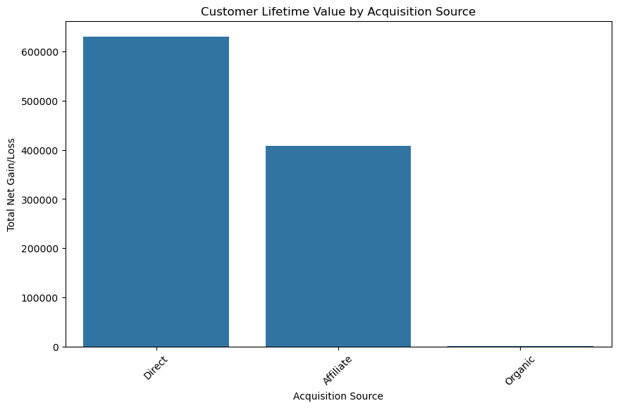

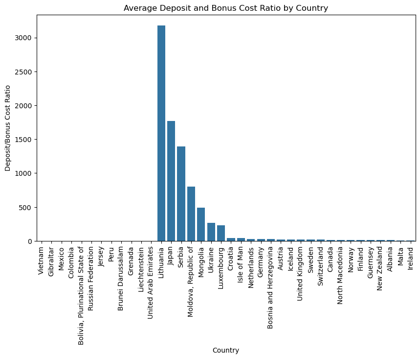

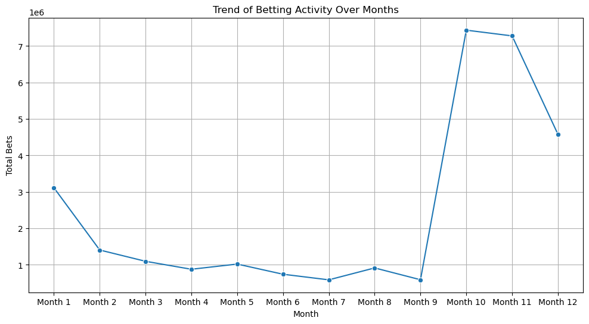

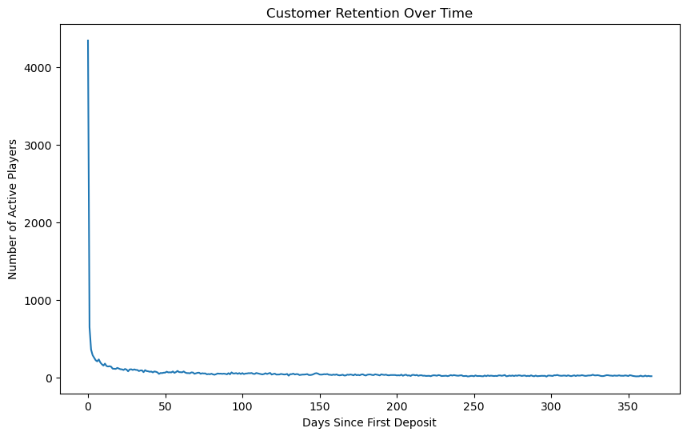

[figure not shown]

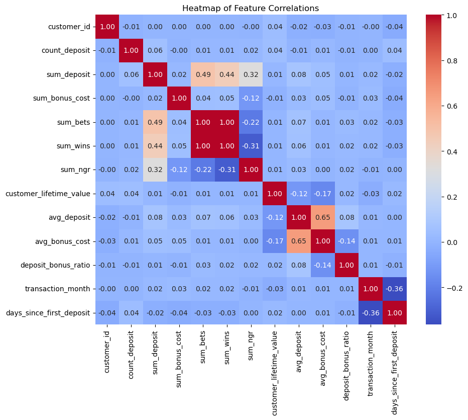

```
+-------+--------------------+--------------------+
|       |      sum_bets      |      sum_wins      |
+-------+--------------------+--------------------+
| count |      22282.0       |      22282.0       |
| mean  | 1330.1223725473476 | 1276.2458118840318 |
|  std  | 10514.747495209267 | 10802.004859306959 |
|  min  |        0.1         |        0.0         |
|  25%  |       58.11        |      37.1825       |
|  50%  | 196.04500000000002 |     150.19205      |
|  75%  | 711.6108750000001  |      635.0675      |
|  max  |    928210.8559     |    1005738.951     |
+-------+--------------------+--------------------+
+-------------------------------+---------------------------+
| Categorical Variable          |   Number of Unique Values |
+===============================+===========================+
| customer_acquisition_source   |                         3 |
+-------------------------------+---------------------------+
| customer_country              |                        38 |
+-------------------------------+---------------------------+
| customer_gender               |                         2 |
+-------------------------------+---------------------------+
| customer_account_created_date |                       414 |
+-------------------------------+---------------------------+
| customer_first_deposit_date   |                        58 |
+-------------------------------+---------------------------+
| transaction_date              |                       402 |
+-------------------------------+---------------------------+
[LightGBM] [Info] Number of positive: 4846, number of negative: 12956
[LightGBM] [Info] Auto-choosing col-wise multi-threading, the overhead of testing was 0.000428 seconds.
You can set `force_col_wise=true` to remove the overhead.
[LightGBM] [Info] Total Bins 1524
[LightGBM] [Info] Number of data points in the train set: 17802, number of used features: 8
[LightGBM] [Info] [binary:BoostFromScore]: pavg=0.500000 -> initscore=-0.000000
[LightGBM] [Info] Start training from score -0.000000
```

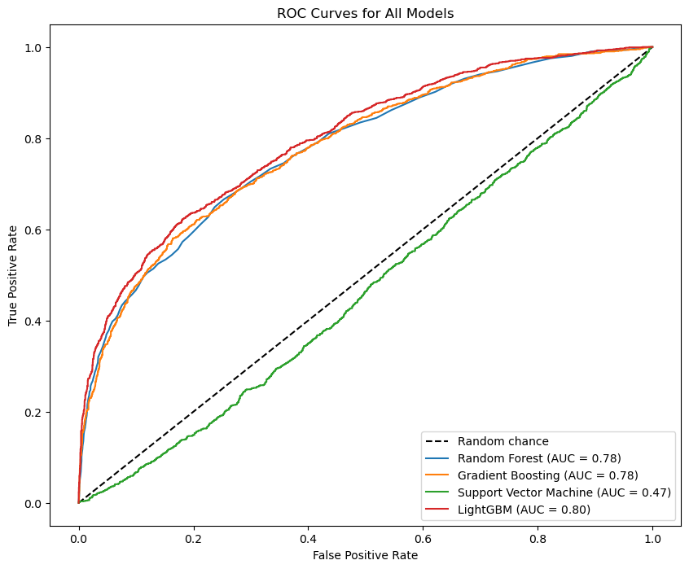

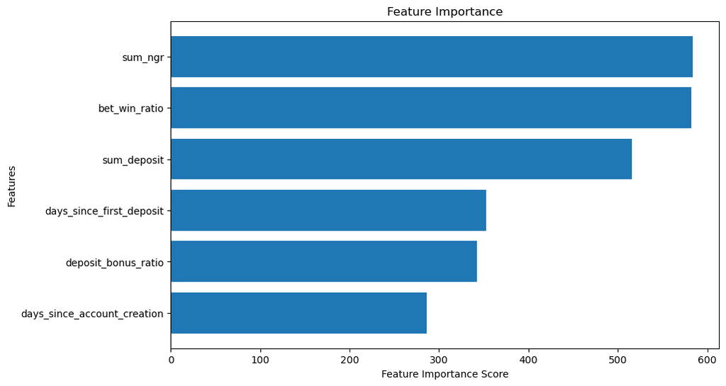

```
Confusion Matrix Results:

Random Forest Confusion Matrix:
+-----------------+--------------------+--------------------+
|                 | Predicted Negative | Predicted Positive |
+-----------------+--------------------+--------------------+
| Actual Negative |        3010        |        220         |
| Actual Positive |        718         |        503         |
+-----------------+--------------------+--------------------+

Gradient Boosting Confusion Matrix:
+-----------------+--------------------+--------------------+
|                 | Predicted Negative | Predicted Positive |
+-----------------+--------------------+--------------------+
| Actual Negative |        3108        |        122         |
| Actual Positive |        837         |        384         |
+-----------------+--------------------+--------------------+

Support Vector Machine Confusion Matrix:
+-----------------+--------------------+--------------------+
|                 | Predicted Negative | Predicted Positive |
+-----------------+--------------------+--------------------+
| Actual Negative |        3230        |         0          |
| Actual Positive |        1221        |         0          |
+-----------------+--------------------+--------------------+

LightGBM Confusion Matrix:
+-----------------+--------------------+--------------------+
|                 | Predicted Negative | Predicted Positive |
+-----------------+--------------------+--------------------+
| Actual Negative |        1354        |        1876        |
| Actual Positive |        124         |        1097        |
+-----------------+--------------------+--------------------+
```

```python
if __name__ == "__main__":
    file_path = "C:/Users/varun/Downloads/data_science_task/data_science_task/task_data_set.csv"
    main(file_path)
```

### Model Performance Interpretations for Confusion Matrix

#### Random Forest Confusion Matrix:

- **True Negatives (TN):** 3010 - The model correctly predicted the negative class 3010 times.
- **False Positives (FP):** 220 - The model incorrectly predicted the positive class 220 times when it was actually negative.
- **False Negatives (FN):** 718 - The model incorrectly predicted the negative class 718 times when it was actually positive.
- **True Positives (TP):** 503 - The model correctly predicted the positive class 503 times.

#### Gradient Boosting Confusion Matrix:

- **TN:** 3108
- **FP:** 122
- **FN:** 837
- **TP:** 384

Gradient Boosting has a higher number of TN and a lower number of FP compared to Random Forest, but it also has a higher FN and lower TP, indicating it is more conservative with predicting the positive class and may not capture as many true positives.

#### Support Vector Machine Confusion Matrix:

- **TN:** 3230
- **FP:** 0
- **FN:** 1221
- **TP:** 0

The Support Vector Machine is the most conservative, predicting all cases as the negative class. This indicates a potential issue with the model, such as imbalanced class weights or an improperly configured decision boundary.

#### LightGBM Confusion Matrix:

- **TN:** 1354
- **FP:** 1876
- **FN:** 124
- **TP:** 1097

LightGBM shows a different pattern, where it predicts more positives at the expense of making more FP errors. It has the highest number of TP predictions but also the highest number of FP predictions.

#### Overall Interpretation:

- **Random Forest** and **Gradient Boosting** are somewhat similar, with the latter being more conservative.
- **Support Vector Machine** is not functioning correctly for the positive class, as it predicts no positive cases at all.
- **LightGBM** is more aggressive in predicting the positive class, which is useful if the cost of missing out on positive cases is high.

In practice, the choice of model may depend on the specific cost of FP versus FN in the context of the problem you are solving. For example:

- If FN (missing a positive case) is very costly, you might prefer a model like **LightGBM**.
- If FP (falsely identifying a negative case as positive) is more costly, you might prefer a model like **Gradient Boosting**.

Another aspect to consider is the imbalance in the dataset. If the positive class is underrepresented, models may tend to predict the majority class. Techniques like resampling, class weights adjustment, or precision-recall analysis might be necessary to handle such cases. The AUC-ROC curve is also a valuable tool here because it evaluates model performance across all classification thresholds.

# Deployment Procedure (Task 3)

#### Flask Application for LightGBM Model Deployment

##### 1. Flask Initialization

- Initializes a new Flask application. **name** signifies the name of the current Python module, allowing Flask to know where to look for resources like templates and static files.

##### 2. Load Pre Trained Model

- Loads the pre-trained LightGBM model using joblib. The model is expected to be saved in a file named lgb_model.joblib. Ensure this file is located in the same directory as the Flask application script or specify the full path to the file.

##### 3. Prediction Endpoint

- Defines a prediction endpoint at the URL path /predict that accepts POST requests. This function will be triggered whenever a POST request is made to this path.
- Extracts JSON data from the incoming POST request. force=True is used to ensure that the incoming data is treated as JSON even if the Content-Type header is not set to application/json.
- Converts the incoming JSON data into a pandas DataFrame. This step is crucial for preprocessing the data consistently, as the model expects input in the form of a DataFrame.
- Applies the same preprocessing steps to the incoming data as were used during the training of the model. It's important that this function is defined elsewhere in your codebase and properly imported into this script. This ensures that the data is in the correct format and scale for prediction.
- Uses the pre-trained LightGBM model to make predictions on the preprocessed data.
- Converts the model's predictions into a list and wraps them in a JSON response, which is then sent back to the client.

##### 4. Running the Flask Application

- Specifies that if the script is executed as the main program, the Flask application should start running. The application will be accessible externally (host='0.0.0.0') on port 5000. debug=True is set for development purposes, providing detailed error messages and enabling live reloading.

```python
# Initialize the Flask application
app = Flask(__name__)

# Load the pre-trained LightGBM model from the specified file.
model = joblib.load('lgb_model.joblib')

# Define the prediction endpoint. The route() decorator tells Flask that this function should be triggered for the URL path '/predict' with the HTTP method POST.
@app.route('/predict', methods=['POST'])
def predict():
    # Parse the JSON payload from the incoming POST request.
    # The force=True argument ensures that only JSON is expected.
    data = request.get_json(force=True)

    # Check if the incoming JSON data is a list (multiple records) or a dictionary (single record).
    # If it's a single record, it's wrapped in a list to create a uniform DataFrame structure.
    # This is important because the preprocessing function expects a DataFrame input.
    df = pd.DataFrame(data if isinstance(data, list) else [data])

    # Preprocess the data using the same function used during model training.
    # This ensures that the new data is transformed in the same way as the training data.
    # The preprocess_data_for_classification function handles both training (with target) and prediction (without target) cases, hence the slicing to ignore the target in the output.
    X, _ = preprocess_data_for_classification(df)

    # Use the model to predict the class labels for the preprocessed data.
    predictions = model.predict(X)

    # Format the predictions as a JSON response to send back to the client.
    # The tolist() method converts the predictions array to a list for JSON serialization.
    return jsonify({'predictions': predictions.tolist()})

# The entry point for running the Flask application.
# The host='0.0.0.0' makes the server accessible externally, and the port number is the entry point for HTTP requests to the server.
if __name__ == '__main__':
    app.run(host='0.0.0.0', port=5000, debug=True)
```